# coursera

2024-08-19

## Loading libraries

To start the script, we first load the necessary libraries. Since this is a machine learning project, we’ll load two of the most commonly used libraries: caret and randomForest. The script is shown below.

```r
library(caret)
library(randomForest)
```

```r
library(ggplot2)
```

## Loading data

The training data for this project are available here: https://d396qusza40orc.cloudfront.net/predmachlearn/pml-training.csv The test data are available here: https://d396qusza40orc.cloudfront.net/predmachlearn/pml-testing.csv. Both files were downloaded to the local machine for easier access.

```r
train_csv <- "C:/Temp/pml-training.csv"
test_csv <- "C:/Temp/pml-testing.csv"

training <- read.csv(train_csv)
testing <- read.csv(test_csv)
```

## Exploratory Data Analysis

```r
str(training)
```

```
## 'data.frame':    19622 obs. of  160 variables:
##  $ X                       : int  1 2 3 4 5 6 7 8 9 10 ...
##  $ user_name               : chr  "carlitos" "carlitos" "carlitos" "carlitos" ...
##  $ raw_timestamp_part_1    : int  1323084231 1323084231 1323084231 1323084232 1323084232 1323084232 1323084232 1323084232 1323084232 1323084232 ...
##  $ raw_timestamp_part_2    : int  788290 808298 820366 120339 196328 304277 368296 440390 484323 484434 ...
##  $ cvtd_timestamp          : chr  "05/12/2011 11:23" "05/12/2011 11:23" "05/12/2011 11:23" "05/12/2011 11:23" ...
##  $ new_window              : chr  "no" "no" "no" "no" ...
##  $ num_window              : int  11 11 11 12 12 12 12 12 12 12 ...
##  $ roll_belt               : num  1.41 1.41 1.42 1.48 1.48 1.45 1.42 1.42 1.43 1.45 ...
##  $ pitch_belt              : num  8.07 8.07 8.07 8.05 8.07 8.06 8.09 8.13 8.16 8.17 ...
##  $ yaw_belt                : num  -94.4 -94.4 -94.4 -94.4 -94.4 -94.4 -94.4 -94.4 -94.4 -94.4 ...
##  $ total_accel_belt        : int  3 3 3 3 3 3 3 3 3 3 ...
##  $ kurtosis_roll_belt      : chr  "" "" "" "" ...
##  $ kurtosis_picth_belt     : chr  "" "" "" "" ...
##  $ kurtosis_yaw_belt       : chr  "" "" "" "" ...
```

[output cut: 86 more lines]

There are a total of 160 columns in the dataset, but not all of them are related to the output variable “classe.” Having too many predictors can reduce the accuracy of the machine learning model. Additionally, since I’m running this on a laptop with limited resources, it’s important to optimize the data. Therefore, we’ll start by removing columns that have no relationship with the output, such as timestamp, sequence ID, and character columns.

```r
training2 <- training[, !names(training) %in% c("X", "user_name", "raw_timestamp_part_1", "raw_timestamp_part_2", "cvtd_timestamp", "new_window", "num_window")]
testing2 <- testing[, !names(testing) %in% c("X", "user_name", "raw_timestamp_part_1", "raw_timestamp_part_2", "cvtd_timestamp", "new_window", "num_window")]
```

```r
na_count <-sapply(training, function(y) sum(length(which(is.na(y)))))
na_count2 <- data.frame(na_count)
na_count3 <- data.frame(var=rownames(na_count2), total=na_count2$na_count)
na_count4 <- na_count3[na_count3$total > 0,]

training3 <- training2[, !names(training2) %in% c(na_count4$var)]
testing3 <- testing2[, !names(testing2) %in% c(na_count4$var)]
```

```r
empty_count <-sapply(training, function(y) sum(length(which(y==""))))
empty_count2 <- data.frame(empty_count)
empty_count3 <- data.frame(var=rownames(empty_count2), total=empty_count2$empty_count)
empty_count4 <- empty_count3[empty_count3$total > 0,]

training4 <- training3[, !names(training3) %in% c(empty_count4$var)]
testing4 <- testing3[, !names(training3) %in% c(empty_count4$var)]
```

Let’s examine the dimensions of the data frame at each step of column reduction. We’ve successfully reduced the number of columns to 53, but this is still quite high.

```r
dim(training)
```

```
## [1] 19622   160
```

```r
dim(training2)
```

```
## [1] 19622   153
```

```r
dim(training3)
```

```
## [1] 19622    86
```

```r
dim(training4)
```

```
## [1] 19622    53
```

## Principle Component Analysis

The next step in reducing the number of columns is to apply Principal Component Analysis (PCA), as we learned in Module 2. We will retain only the principal components that account for 80% of the variance.

```r
pca_training <- prcomp(training4[, !names(training4) %in% c("classe")],center = TRUE, scale. = TRUE)
pca_testing <- prcomp(testing4[, !names(testing4) %in% c("classe")],center = TRUE, scale. = TRUE)

cumulative_variance <- cumsum(pca_training$sdev^2 / sum(pca_training$sdev^2))
num_components <- which(cumulative_variance >= 0.80)[1]
num_components
```

```
## [1] 12
```

```r
training5 <- cbind(data.frame(classe=training4$classe), data.frame(pca_training$x[,c(1:num_components)]))
testing5 <- data.frame(pca_testing$x[,c(1:num_components)])
```

The next step is to split the training dataset into a training set and a validation set with a 70% to 30% ratio.

```r
inTrain <- createDataPartition(y=training5$classe,p=0.7, list=FALSE)
training6<- training5[inTrain,]
validation6<- training5[-inTrain,]
```

## Model Training and Validating

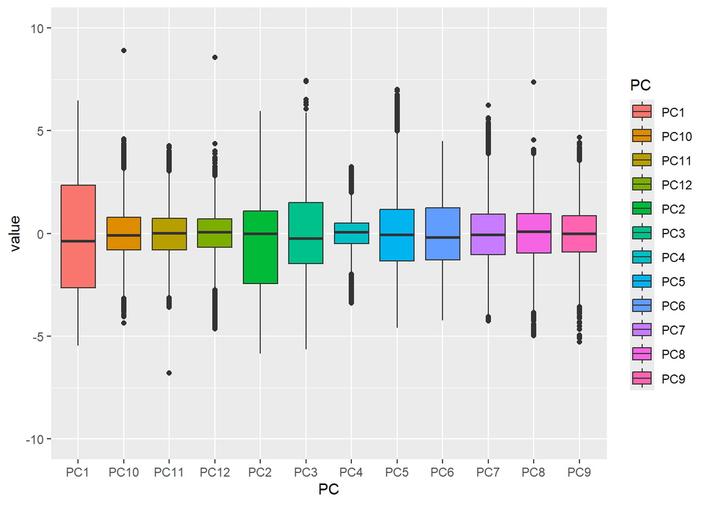

```r
PC1 <- data.frame(PC="PC1", value=training6$PC1)
PC2 <- data.frame(PC="PC2", value=training6$PC2)
PC3 <- data.frame(PC="PC3", value=training6$PC3)
PC4 <- data.frame(PC="PC4", value=training6$PC4)
PC5 <- data.frame(PC="PC5", value=training6$PC5)
PC6 <- data.frame(PC="PC6", value=training6$PC6)
PC7 <- data.frame(PC="PC7", value=training6$PC7)
PC8 <- data.frame(PC="PC8", value=training6$PC8)
PC9 <- data.frame(PC="PC9", value=training6$PC9)
PC10 <- data.frame(PC="PC10", value=training6$PC10)
PC11 <- data.frame(PC="PC11", value=training6$PC11)
PC12 <- data.frame(PC="PC12", value=training6$PC12)
PC_data <- rbind(PC1, PC2, PC3, PC4, PC5, PC6, PC7, PC8, PC9, PC10,PC11,PC12)

qplot(PC, value, data=PC_data, fill=PC, geom=c("boxplot")) + ylim(c(-10,10))
```

## Model Training and Validating

For this homework, the random forest model was chosen. Cross-validation was incorporated into the model training, with the minimum number of folds selected due to the laptop’s resource limitations. The model was then validated using the validation dataset, achieving an accuracy greater than 0.95, which is excellent.

```r
set.seed(123)
rf_model <- train(classe ~ ., data = training6, method = "rf", trControl = trainControl(method = "cv", number = 2))

rf_pred <- predict(rf_model, validation6)
confusionMatrix(rf_pred, factor(validation6$classe))
```

```
## Confusion Matrix and Statistics
##
##           Reference
## Prediction    A    B    C    D    E
##          A 1634   24    9   10    3
##          B    9 1074   15    3    2
##          C   20   29  975   50    2
##          D   10   11   19  901    7
##          E    1    1    8    0 1068
##
## Overall Statistics
##
##                Accuracy : 0.9604
##                  95% CI : (0.9551, 0.9652)
##     No Information Rate : 0.2845
##     P-Value [Acc > NIR] : < 2.2e-16
##
##                   Kappa : 0.9499
##
##  Mcnemar's Test P-Value : 1.509e-06
##
## Statistics by Class:
##
##                      Class: A Class: B Class: C Class: D Class: E
## Sensitivity            0.9761   0.9429   0.9503   0.9346   0.9871
## Specificity            0.9891   0.9939   0.9792   0.9904   0.9979
## Pos Pred Value         0.9726   0.9737   0.9061   0.9504   0.9907
## Neg Pred Value         0.9905   0.9864   0.9894   0.9872   0.9971
## Prevalence             0.2845   0.1935   0.1743   0.1638   0.1839
## Detection Rate         0.2777   0.1825   0.1657   0.1531   0.1815
## Detection Prevalence   0.2855   0.1874   0.1828   0.1611   0.1832
## Balanced Accuracy      0.9826   0.9684   0.9648   0.9625   0.9925
```

## Predicting Testing Dataset

The importance of the variables was examined. The trained model was then used to make predictions on the testing dataset.

```r
varImp(rf_model)
```

```
## rf variable importance
##
##      Overall
## PC12  100.00
## PC8    98.04
## PC5    70.07
## PC1    69.85
## PC9    53.16
## PC3    51.87
## PC6    39.80
## PC2    36.61
## PC10   17.86
## PC7    14.82
## PC4    14.44
## PC11    0.00
```

```r
rf_pred2 <- predict(rf_model, testing5)
```